# COSC 4337 - Homework 2: MLP for Multi-Class Classification

**Objective:** The goal of this assignment is to build, train, and evaluate a Multi-Layer Perceptron (MLP) neural network for a multi-class classification task.

***Note on Frameworks***

This notebook uses `Keras` with a `TensorFlow`. If you are more comfortable with `PyTorch`, you are welcome to complete the assignment using it. The core concepts of defining layers, choosing activation/loss functions, and training the model are directly transferable. Feel free to change code as you see fit as long as it follows the tasks, you don't lose points for going above and beyond.

## Problem Statement

You are tasked with classifying iris flowers into one of three species (*Setosa*, *Versicolour*, or *Virginica*) based on four physical measurements. This is a classic machine learning problem that will allow you to apply your knowledge of neural network architectures in a hands-on way.

**Dataset Features (Inputs):**

1. Sepal Length (cm)
2. Sepal Width (cm)
3. Petal Length (cm)
4. Petal Width (cm)

**Dataset Target (Output):**

- Iris Species (3 classes)

Link to dataset: https://archive.ics.uci.edu/dataset/53/iris (This has been imported from sklearn below)

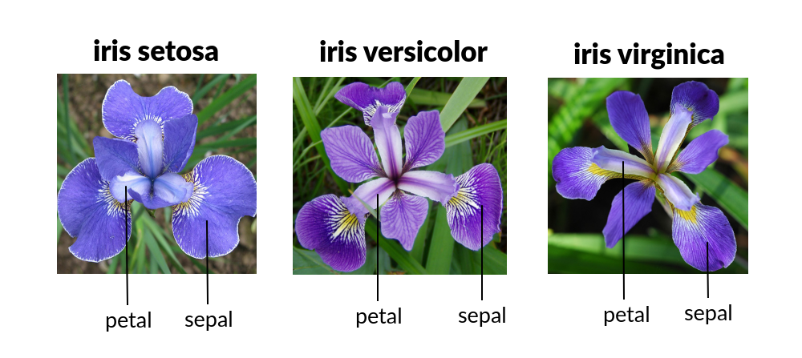

```python
# Import necessary libraries (you can use pytorch if you want to)
import numpy as np
import pandas as pd
from tensorflow import random
from keras.models import Sequential
from keras.layers import Dense
from sklearn.model_selection import train_test_split
from sklearn.preprocessing import StandardScaler, OneHotEncoder
from sklearn.datasets import load_iris
import matplotlib.pyplot as plt # You can use seaborn if you prefer

# Set a seed for reproducibility
seed = 4337
np.random.seed(seed)
random.set_seed(seed)
```

## Data Loading and Preprocessing

First, we will load the Iris dataset from `scikit-learn`. Then, we must preprocess it for our neural network. This involves two key steps:

1. **Scaling the Features**: Neural networks perform best when numerical input features are scaled to a standard range. We will use `StandardScaler`.
2. **One-Hot Encoding the Target**: Our target variable has three classes (0, 1, 2). For multi-class classification with a `categorical_crossentropy` loss function, we must convert these integer labels into a "one-hot" format (e.g., class `1` becomes `[0, 1, 0]`).

```python
# Load the dataset
iris = load_iris()
X = iris.data
y = iris.target.reshape(-1, 1) # Reshape for the encoder

# Preprocessing Steps
# 1. Scale the features
scaler = StandardScaler()
X_scaled = scaler.fit_transform(X)

# 2. One-hot encode the target variable
encoder = OneHotEncoder(sparse_output=False)
y_onehot = encoder.fit_transform(y)

# 3. Split the data into training and testing sets
# YOUR CODE HERE: Fill in the parameters to split with a 20% test size and use the 'seed' for reproducibility
X_train, X_test, y_train, y_test = train_test_split(X_scaled, y_onehot, test_size=0.2, random_state=seed)

# Print the shapes to verify
print("Shape of X_train:", X_train.shape)
print("Shape of y_train:", y_train.shape)
print("Shape of X_test:", X_test.shape)
print("Shape of y_test:", y_test.shape)
```

```
Shape of X_train: (120, 4)
Shape of y_train: (120, 3)
Shape of X_test: (30, 4)
Shape of y_test: (30, 3)
```

## Exercise 1: Build and Compare MLP Models

Your task is to define, compile, and train three different MLP architectures. Each model should use the `relu` activation function for its hidden layers. The output layer for **all models** must have **3 neurons** (one for each class) and use the **`softmax`** activation function.

- **Model 1 (Baseline):** A simple network with 2 hidden layers, each with 8 neurons.
  - `Input -> Dense(8, relu) -> Dense(8, relu) -> Dense(3, softmax)`
- **Model 2 (Deeper):** A deeper network with 4 hidden layers, each with 8 neurons.
  - `Input -> Dense(8, relu) -> Dense(8, relu) -> Dense(8, relu) -> Dense(8, relu) -> Dense(3, softmax)`
- **Model 3 (Wider):** A wider network with 2 hidden layers, each with 16 neurons.
  - `Input -> Dense(16, relu) -> Dense(16, relu) -> Dense(3, softmax)`

Compile each model using the `adam` optimizer and `categorical_crossentropy` as the loss function.

```python
# Get the number of input features
n_features = X_train.shape[1]

# --- Define Model 1 (Baseline) ---
model_1 = Sequential()
model_1.add(Dense(8, activation='relu', input_shape=(n_features,)))
# YOUR CODE HERE: Add the second hidden layer with 8 neurons and a 'relu' activation
model_1.add(Dense(8, activation='relu'))
# YOUR CODE HERE: Add the output layer with 3 neurons and a 'softmax' activation
model_1.add(Dense(3, activation='softmax'))

# --- Define Model 2 (Deeper) ---
model_2 = Sequential()
model_2.add(Dense(8, activation='relu', input_shape=(n_features,)))
# YOUR CODE HERE: Add three more hidden layers, each with 8 neurons and a 'relu' activation
model_2.add(Dense(8, activation='relu'))
model_2.add(Dense(8, activation='relu'))
model_2.add(Dense(8, activation='relu'))
# YOUR CODE HERE: Add the output layer
model_2.add(Dense(3, activation='softmax'))

# --- Define Model 3 (Wider) ---
model_3 = Sequential()
model_3.add(Dense(16, activation='relu', input_shape=(n_features,)))
# YOUR CODE HERE: Add the second hidden layer with 16 neurons and a 'relu' activation
model_3.add(Dense(16, activation='relu'))
# YOUR CODE HERE: Add the output layer
model_3.add(Dense(3, activation='softmax'))

# --- Compile the models ---
# YOUR CODE HERE: Compile model_1 with the 'adam' optimizer and 'categorical_crossentropy' for loss
model_1.compile(optimizer='adam', loss='categorical_crossentropy', metrics=['accuracy'])

# YOUR CODE HERE: Compile model_2 and model_3 with the same parameters
model_2.compile(optimizer='adam', loss='categorical_crossentropy', metrics=['accuracy'])
model_3.compile(optimizer='adam', loss='categorical_crossentropy', metrics=['accuracy'])

# --- Print a summary of one of the models ---
print("--- Model 3 (Wider) Summary ---")
model_3.summary()
```

```
--- Model 3 (Wider) Summary ---
```

```
Model: "sequential_2"
```

```
┏━━━━━━━━━━━━━━━━━━━━━━━━━━━━━━━━━┳━━━━━━━━━━━━━━━━━━━━━━━━┳━━━━━━━━━━━━━━━┓
┃ Layer (type)                    ┃ Output Shape           ┃       Param # ┃
┡━━━━━━━━━━━━━━━━━━━━━━━━━━━━━━━━━╇━━━━━━━━━━━━━━━━━━━━━━━━╇━━━━━━━━━━━━━━━┩
│ dense_8 (Dense)                 │ (None, 16)             │            80 │
├─────────────────────────────────┼────────────────────────┼───────────────┤
│ dense_9 (Dense)                 │ (None, 16)             │           272 │
├─────────────────────────────────┼────────────────────────┼───────────────┤
│ dense_10 (Dense)                │ (None, 3)              │            51 │
└─────────────────────────────────┴────────────────────────┴───────────────┘
```

```
 Total params: 403 (1.57 KB)
```

```
 Trainable params: 403 (1.57 KB)
```

```
 Non-trainable params: 0 (0.00 B)
```

### Train the Models

Now, train each model on the training data for `50` epochs with a `batch_size` of `5`. We will store the training history to plot the learning curves later. **Feel free to adjust epochs if training time is too long.**

```python
# Training parameters
epochs = 50
batch_size = 5

print("Training Model 1 (Baseline)...")
# YOUR CODE HERE: Train model_1 using the .fit() method. Use the training data,
# specified epochs and batch_size, and set validation_split to 0.1
history_1 = model_1.fit(X_train, y_train, epochs=epochs, batch_size=batch_size, validation_split=0.1)

print("Training Model 2 (Deeper)...")
# YOUR CODE HERE: Train model_2
history_2 = model_2.fit(X_train, y_train, epochs=epochs, batch_size=batch_size, validation_split=0.1)

print("Training Model 3 (Wider)...")
# YOUR CODE HERE: Train model_3
history_3 = model_2.fit(X_train, y_train, epochs=epochs, batch_size=batch_size, validation_split=0.1)

print("\nAll models trained successfully! 🎉")
```

```
Training Model 1 (Baseline)...
22/22 ━━━━━━━━━━━━━━━━━━━━ 1s 14ms/step - accuracy: 0.3047 - loss: 1.4587 - val_accuracy: 0.4167 - val_loss: 1.3107
22/22 ━━━━━━━━━━━━━━━━━━━━ 0s 5ms/step - accuracy: 0.3047 - loss: 1.3035 - val_accuracy: 0.5000 - val_loss: 1.1775
22/22 ━━━━━━━━━━━━━━━━━━━━ 0s 5ms/step - accuracy: 0.3159 - loss: 1.1880 - val_accuracy: 0.5833 - val_loss: 1.0690
22/22 ━━━━━━━━━━━━━━━━━━━━ 0s 5ms/step - accuracy: 0.4388 - loss: 1.0927 - val_accuracy: 0.5833 - val_loss: 0.9790
22/22 ━━━━━━━━━━━━━━━━━━━━ 0s 5ms/step - accuracy: 0.5231 - loss: 1.0125 - val_accuracy: 0.5833 - val_loss: 0.9004
22/22 ━━━━━━━━━━━━━━━━━━━━ 0s 5ms/step - accuracy: 0.5553 - loss: 0.9458 - val_accuracy: 0.5833 - val_loss: 0.8352
22/22 ━━━━━━━━━━━━━━━━━━━━ 0s 5ms/step - accuracy: 0.5228 - loss: 0.8911 - val_accuracy: 0.5833 - val_loss: 0.7826
22/22 ━━━━━━━━━━━━━━━━━━━━ 0s 5ms/step - accuracy: 0.5155 - loss: 0.8469 - val_accuracy: 0.5833 - val_loss: 0.7397
22/22 ━━━━━━━━━━━━━━━━━━━━ 0s 5ms/step - accuracy: 0.5638 - loss: 0.8112 - val_accuracy: 0.5833 - val_loss: 0.7054
22/22 ━━━━━━━━━━━━━━━━━━━━ 0s 5ms/step - accuracy: 0.6138 - loss: 0.7822 - val_accuracy: 0.7500 - val_loss: 0.6769
22/22 ━━━━━━━━━━━━━━━━━━━━ 0s 5ms/step - accuracy: 0.6227 - loss: 0.7581 - val_accuracy: 0.7500 - val_loss: 0.6529
22/22 ━━━━━━━━━━━━━━━━━━━━ 0s 5ms/step - accuracy: 0.6513 - loss: 0.7380 - val_accuracy: 0.7500 - val_loss: 0.6342
22/22 ━━━━━━━━━━━━━━━━━━━━ 0s 5ms/step - accuracy: 0.6688 - loss: 0.7213 - val_accuracy: 0.7500 - val_loss: 0.6177
22/22 ━━━━━━━━━━━━━━━━━━━━ 0s 5ms/step - accuracy: 0.6565 - loss: 0.7062 - val_accuracy: 0.7500 - val_loss: 0.6025
22/22 ━━━━━━━━━━━━━━━━━━━━ 0s 5ms/step - accuracy: 0.6969 - loss: 0.6925 - val_accuracy: 0.7500 - val_loss: 0.5891
22/22 ━━━━━━━━━━━━━━━━━━━━ 0s 5ms/step - accuracy: 0.6899 - loss: 0.6794 - val_accuracy: 0.7500 - val_loss: 0.5755
22/22 ━━━━━━━━━━━━━━━━━━━━ 0s 5ms/step - accuracy: 0.7093 - loss: 0.6665 - val_accuracy: 0.7500 - val_loss: 0.5617
22/22 ━━━━━━━━━━━━━━━━━━━━ 0s 5ms/step - accuracy: 0.7285 - loss: 0.6531 - val_accuracy: 0.7500 - val_loss: 0.5456
22/22 ━━━━━━━━━━━━━━━━━━━━ 0s 5ms/step - accuracy: 0.7311 - loss: 0.6387 - val_accuracy: 0.9167 - val_loss: 0.5249
22/22 ━━━━━━━━━━━━━━━━━━━━ 0s 4ms/step - accuracy: 0.7311 - loss: 0.6221 - val_accuracy: 0.9167 - val_loss: 0.4999
22/22 ━━━━━━━━━━━━━━━━━━━━ 0s 5ms/step - accuracy: 0.7742 - loss: 0.6036 - val_accuracy: 0.9167 - val_loss: 0.4722
22/22 ━━━━━━━━━━━━━━━━━━━━ 0s 4ms/step - accuracy: 0.7804 - loss: 0.5827 - val_accuracy: 0.9167 - val_loss: 0.4412
22/22 ━━━━━━━━━━━━━━━━━━━━ 0s 5ms/step - accuracy: 0.7821 - loss: 0.5589 - val_accuracy: 0.9167 - val_loss: 0.4074
22/22 ━━━━━━━━━━━━━━━━━━━━ 0s 4ms/step - accuracy: 0.7667 - loss: 0.5327 - val_accuracy: 0.9167 - val_loss: 0.3753
22/22 ━━━━━━━━━━━━━━━━━━━━ 0s 4ms/step - accuracy: 0.7794 - loss: 0.5065 - val_accuracy: 0.9167 - val_loss: 0.3465
22/22 ━━━━━━━━━━━━━━━━━━━━ 0s 5ms/step - accuracy: 0.8040 - loss: 0.4810 - val_accuracy: 0.9167 - val_loss: 0.3216
22/22 ━━━━━━━━━━━━━━━━━━━━ 0s 5ms/step - accuracy: 0.8040 - loss: 0.4565 - val_accuracy: 0.9167 - val_loss: 0.3009
22/22 ━━━━━━━━━━━━━━━━━━━━ 0s 6ms/step - accuracy: 0.8382 - loss: 0.4337 - val_accuracy: 0.9167 - val_loss: 0.2840
22/22 ━━━━━━━━━━━━━━━━━━━━ 0s 5ms/step - accuracy: 0.8382 - loss: 0.4131 - val_accuracy: 0.9167 - val_loss: 0.2697
22/22 ━━━━━━━━━━━━━━━━━━━━ 0s 7ms/step - accuracy: 0.8394 - loss: 0.3945 - val_accuracy: 0.9167 - val_loss: 0.2575
22/22 ━━━━━━━━━━━━━━━━━━━━ 0s 4ms/step - accuracy: 0.8394 - loss: 0.3772 - val_accuracy: 0.9167 - val_loss: 0.2471
22/22 ━━━━━━━━━━━━━━━━━━━━ 0s 4ms/step - accuracy: 0.8494 - loss: 0.3610 - val_accuracy: 0.9167 - val_loss: 0.2382
22/22 ━━━━━━━━━━━━━━━━━━━━ 0s 5ms/step - accuracy: 0.8689 - loss: 0.3458 - val_accuracy: 0.9167 - val_loss: 0.2299
22/22 ━━━━━━━━━━━━━━━━━━━━ 0s 4ms/step - accuracy: 0.8689 - loss: 0.3314 - val_accuracy: 0.9167 - val_loss: 0.2221
22/22 ━━━━━━━━━━━━━━━━━━━━ 0s 4ms/step - accuracy: 0.8895 - loss: 0.3178 - val_accuracy: 0.9167 - val_loss: 0.2152
22/22 ━━━━━━━━━━━━━━━━━━━━ 0s 5ms/step - accuracy: 0.9038 - loss: 0.3047 - val_accuracy: 0.9167 - val_loss: 0.2101
22/22 ━━━━━━━━━━━━━━━━━━━━ 0s 5ms/step - accuracy: 0.9196 - loss: 0.2914 - val_accuracy: 0.9167 - val_loss: 0.2047
22/22 ━━━━━━━━━━━━━━━━━━━━ 0s 4ms/step - accuracy: 0.9196 - loss: 0.2788 - val_accuracy: 0.9167 - val_loss: 0.1990
22/22 ━━━━━━━━━━━━━━━━━━━━ 0s 4ms/step - accuracy: 0.9196 - loss: 0.2666 - val_accuracy: 0.9167 - val_loss: 0.1940
```

[output cut: 100 more lines]

```
22/22 ━━━━━━━━━━━━━━━━━━━━ 0s 5ms/step - accuracy: 0.9812 - loss: 0.0326 - val_accuracy: 1.0000 - val_loss: 0.1044
22/22 ━━━━━━━━━━━━━━━━━━━━ 0s 5ms/step - accuracy: 0.9812 - loss: 0.0327 - val_accuracy: 1.0000 - val_loss: 0.1002
22/22 ━━━━━━━━━━━━━━━━━━━━ 0s 5ms/step - accuracy: 0.9812 - loss: 0.0321 - val_accuracy: 1.0000 - val_loss: 0.0967
22/22 ━━━━━━━━━━━━━━━━━━━━ 0s 5ms/step - accuracy: 0.9812 - loss: 0.0317 - val_accuracy: 1.0000 - val_loss: 0.0997
22/22 ━━━━━━━━━━━━━━━━━━━━ 0s 6ms/step - accuracy: 0.9812 - loss: 0.0321 - val_accuracy: 1.0000 - val_loss: 0.0953
22/22 ━━━━━━━━━━━━━━━━━━━━ 0s 5ms/step - accuracy: 0.9812 - loss: 0.0315 - val_accuracy: 1.0000 - val_loss: 0.0921
22/22 ━━━━━━━━━━━━━━━━━━━━ 0s 5ms/step - accuracy: 0.9812 - loss: 0.0310 - val_accuracy: 1.0000 - val_loss: 0.0944
22/22 ━━━━━━━━━━━━━━━━━━━━ 0s 5ms/step - accuracy: 0.9812 - loss: 0.0309 - val_accuracy: 1.0000 - val_loss: 0.0917
22/22 ━━━━━━━━━━━━━━━━━━━━ 0s 5ms/step - accuracy: 0.9812 - loss: 0.0305 - val_accuracy: 1.0000 - val_loss: 0.0960
22/22 ━━━━━━━━━━━━━━━━━━━━ 0s 4ms/step - accuracy: 0.9812 - loss: 0.0310 - val_accuracy: 1.0000 - val_loss: 0.0919
22/22 ━━━━━━━━━━━━━━━━━━━━ 0s 5ms/step - accuracy: 0.9812 - loss: 0.0305 - val_accuracy: 1.0000 - val_loss: 0.0885
22/22 ━━━━━━━━━━━━━━━━━━━━ 0s 8ms/step - accuracy: 0.9812 - loss: 0.0299 - val_accuracy: 1.0000 - val_loss: 0.0853
22/22 ━━━━━━━━━━━━━━━━━━━━ 0s 5ms/step - accuracy: 0.9812 - loss: 0.0299 - val_accuracy: 1.0000 - val_loss: 0.0887

All models trained successfully! 🎉
```

### Evaluate Model Performance

```python
# Evaluate Model 1
loss_1, accuracy_1 = model_1.evaluate(X_test, y_test, verbose=0)
print(f"Model 1 (Baseline) - Test Accuracy: {accuracy_1:.4f}")

# Evaluate Model 2
loss_2, accuracy_2 = model_2.evaluate(X_test, y_test, verbose=0)
print(f"Model 2 (Baseline) - Test Accuracy: {accuracy_2:.4f}")

# Evaluate Model 3
loss_3, accuracy_3 = model_3.evaluate(X_test, y_test, verbose=0)
print(f"Model 3 (Baseline) - Test Accuracy: {accuracy_3:.4f}")
```

```
Model 1 (Baseline) - Test Accuracy: 0.9000
Model 2 (Baseline) - Test Accuracy: 0.9667
Model 3 (Baseline) - Test Accuracy: 0.5667
```

## More Evaluation Techniques

While accuracy gives us a good top-level score, it doesn't tell the whole story. Let's dig deeper.

### A. Plotting Learning Curves

Plotting the model's accuracy and loss on both the training and validation sets over epochs can help us understand the training process. It's a great way to spot **overfitting** (when the model performs well on training data but poorly on new data).

### B. Confusion Matrix & Classification Report

For classification tasks, a **confusion matrix** shows us exactly which classes the model is confusing. A **classification report** provides key metrics like **precision**, **recall**, and **F1-score** for each class.

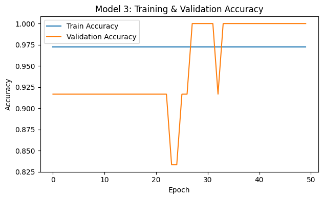

```python
from sklearn.metrics import classification_report, confusion_matrix

# --- A. Plotting Learning Curves ---
# one has been done for you
history = history_3
plt.figure(figsize=(12, 4))

# Plot Training & Validation Accuracy
plt.subplot(1, 2, 1)
plt.plot(history.history['accuracy'], label='Train Accuracy')
plt.plot(history.history['val_accuracy'], label='Validation Accuracy')
plt.title('Model 3: Training & Validation Accuracy')
plt.xlabel('Epoch')
plt.ylabel('Accuracy')
plt.legend()

# Similarly Plot Training & Validation Loss
plt.tight_layout()
plt.show()
```

```python
# --- Experiment with Optimizers ---
# Model Definitions:
def build_model():
    model = Sequential()
    model.add(Dense(16, activation='relu', input_shape=(n_features,)))
    model.add(Dense(16, activation='relu'))
    model.add(Dense(3, activation='softmax'))
    return model

# YOUR CODE HERE: Compile model_sgd with the 'sgd' optimizer
model_sgd = build_model()
model_sgd.compile(optimizer='sgd', loss='categorical_crossentropy', metrics=['accuracy'])

# YOUR CODE HERE: Compile model_rmsprop with the 'rmsprop' optimizer
model_rmsprop = build_model()
model_rmsprop.compile(optimizer='rmsprop', loss='categorical_crossentropy', metrics=['accuracy'])

# # ... Training and Evaluation Code ...
# model.fit(X_test, y_test, validation_split=0.2)

# # --- Add Dropout ---
# from keras.layers import Dropout

# model_dropout = Sequential([
#     Dense(16, activation='relu', input_shape=(n_features,)),
#     # YOUR CODE HERE: Add a Dropout layer with a rate of 0.2
#     Dropout(0.2),
#     Dense(16, activation='relu'),
#     Dense(3, activation='softmax')
# ])

# # ... (compile and training code) ...
```

```
Training with SGD optimizer...
SGD Optimizer - Test Accuracy: 1.0000
Training with RMSprop optimizer...
RMSprop Optimizer - Test Accuracy: 0.9667
```

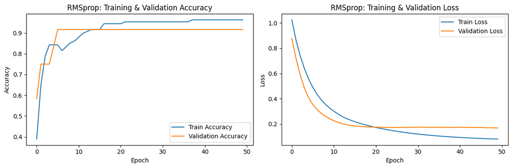

```
Training model with Dropout...
Dropout Model - Test Accuracy: 1.0000
1/1 ━━━━━━━━━━━━━━━━━━━━ 0s 75ms/step

Classification Report (Dropout Model):
              precision    recall  f1-score   support

      setosa       1.00      1.00      1.00        12
  versicolor       1.00      1.00      1.00        14
   virginica       1.00      1.00      1.00         4

    accuracy                           1.00        30
   macro avg       1.00      1.00      1.00        30
weighted avg       1.00      1.00      1.00        30

Confusion Matrix (Dropout Model):
[[12  0  0]
 [ 0 14  0]
 [ 0  0  4]]
```

```python
# --- Train and Evaluate Optimizer Models ---
print("Training with SGD optimizer...")
history_sgd = model_sgd.fit(X_train, y_train, epochs=50, batch_size=5, validation_split=0.1, verbose=0)
loss_sgd, acc_sgd = model_sgd.evaluate(X_test, y_test, verbose=0)
print(f"SGD Optimizer - Test Accuracy: {acc_sgd:.4f}")

print("Training with RMSprop optimizer...")
history_rmsprop = model_rmsprop.fit(X_train, y_train, epochs=50, batch_size=5, validation_split=0.1, verbose=0)
loss_rmsprop, acc_rmsprop = model_rmsprop.evaluate(X_test, y_test, verbose=0)
print(f"RMSprop Optimizer - Test Accuracy: {acc_rmsprop:.4f}")


# --- A. Plotting Learning Curves ---
# Plot training/validation accuracy and loss for the RMSprop model
history = history_rmsprop
plt.figure(figsize=(12, 4))

# Plot Training & Validation Accuracy
plt.subplot(1, 2, 1)
plt.plot(history.history['accuracy'], label='Train Accuracy')
plt.plot(history.history['val_accuracy'], label='Validation Accuracy')
plt.title('RMSprop: Training & Validation Accuracy')
plt.xlabel('Epoch')
plt.ylabel('Accuracy')
plt.legend()

# Plot Training & Validation Loss
plt.subplot(1, 2, 2)
plt.plot(history.history['loss'], label='Train Loss')
plt.plot(history.history['val_loss'], label='Validation Loss')
plt.title('RMSprop: Training & Validation Loss')
plt.xlabel('Epoch')
plt.ylabel('Loss')
plt.legend()

plt.tight_layout()
plt.show()


# --- Add Dropout ---
from keras.layers import Dropout

model_dropout = Sequential([
    Dense(16, activation='relu', input_shape=(n_features,)),
    # YOUR CODE HERE: Add a Dropout layer with a rate of 0.2
    Dropout(0.2),
    Dense(16, activation='relu'),
    Dense(3, activation='softmax')
])

# Compile model_dropout
model_dropout.compile(optimizer='adam', loss='categorical_crossentropy', metrics=['accuracy'])

# Train and evaluate model_dropout
print("Training model with Dropout...")
history_dropout = model_dropout.fit(X_train, y_train, epochs=50, batch_size=5, validation_split=0.1, verbose=0)
loss_dropout, acc_dropout = model_dropout.evaluate(X_test, y_test, verbose=0)
print(f"Dropout Model - Test Accuracy: {acc_dropout:.4f}")


# --- B. Confusion Matrix & Classification Report ---
# Get predictions for the dropout model
y_pred_probs = model_dropout.predict(X_test)
y_pred = np.argmax(y_pred_probs, axis=1)
y_true = np.argmax(y_test, axis=1)

# Print classification report
print("\nClassification Report (Dropout Model):")
print(classification_report(y_true, y_pred, target_names=iris.target_names))

# Print confusion matrix
print("Confusion Matrix (Dropout Model):")
print(confusion_matrix(y_true, y_pred))
```

## Exercise 3: Analysis and Questions

Answer the following questions in the markdown cell below.

1. **Which of the three models performed the best on the test data?** List its architecture and final test accuracy.

Model 2 performed the best on the test data with a final test accuracy of 0.9667. Its architecture consists of four hidden layers with 8 neurons each.

2. **Why do you think the best-performing model was more successful than the others for this specific dataset?** (Consider the complexity of the problem and the model's architecture - depth vs. width).

Model 2 outperfromed the two other models because of its deeper architecture allowing it to capture more complex relationships in the data without overfitting.

3. **Explain the role of the `softmax` activation function in the output layer.** Why is it essential for this multi-class classification problem instead of `sigmoid`?

The role of the softmax activation function in the output layer, is to help in transforming output values into a format that can be interpreted as probabilities that sum up to 1, making it suitable for classification tasks.

Softmax is essential for multi-class classification problems because it enforces mutual exclusivity among classes. In contrast, the sigmoid function treats each output independently and does not ensure the probabilities add up to 1, making it more suitable for multi-label problems rather than single-label multi-class classification.

4. **We converted the target labels (0, 1, 2) into vectors like `[1,0,0]`, `[0,1,0]`, etc. This is called One-Hot Encoding.** Why is this step necessary when using the `categorical_crossentropy` loss function?

One-Hot Encoding is involved in the preprocessing (which is an integral part of the Neural Networking process where we prepare the data for the neural network). One-Hot Engcoding is a method for converting categorical variables into a binary format, with the goal for categorical data to be more effectively used in machine learning models.

5. **Confusion Matrix Analysis:** Did your best model confuse any of the classes? If so, which ones? (e.g., "It often misclassified 'versicolor' as 'virginica'.").

6. **Learning Curves:** Look at the learning curve plots from the "Advanced Evaluation" section. Did the validation accuracy continue to improve for all 50 epochs, or did it plateau or get worse? What does this suggest about the number of epochs chosen?

The validation accuracy throughout the epochs plateaued by the 6th epoch. This sort of means that at least for the validation accuracy, we did not need to have 50 epochs and could have done well with less

7. **Tuning Results:** Briefly summarize your findings from Exercise 3. How did the `sgd` and `rmsprop` optimizers compare to `adam`? Did adding a `Dropout` layer help, hurt, or have little effect on performance for this dataset?

## 4. Deliverables

Please submit:

1. This completed Jupyter Notebook file (`.ipynb`).
2. An exported HTML version of this notebook (`File -> Download as -> HTML`). 25% penalty for not doing so.